# Project: Identify Customer Segments

In this project, we will apply unsupervised learning techniques to identify segments of the population that form the core customer base for a mail-order sales company in Germany. These segments can then be used to direct marketing campaigns towards audiences that will have the highest expected rate of returns. The data used represents a real-life data science task, provided by Arvato in cooperation with Udacity. The data is private, and is thus not provided in this repository. However, the techniques employed can be used on many other data science problems.

```python
# import libraries here; add more as necessary
import numpy as np
import pandas as pd
import matplotlib.pyplot as plt
import seaborn as sns
from sklearn.preprocessing import Imputer
from sklearn.preprocessing import StandardScaler
from sklearn.decomposition import PCA
from sklearn.cluster import KMeans
from scipy.stats import itemfreq

# magic word for producing visualizations in notebook
%matplotlib inline
```

### Step 0: Load the Data

Each row of the demographics files represents a single person, but also includes information outside of individuals, including information about their household, building, and neighborhood. This information will be used to cluster the general population into groups with similar demographic properties. Then, we will see how the people in the customers dataset fit into those created clusters. The hope here is that certain clusters are over-represented in the customers data, as compared to the general population; those over-represented clusters will be assumed to be part of the core userbase. This information can then be used for further applications, such as targeting for a marketing campaign.

To start off with, load in the demographics data for the general population into a pandas DataFrame, and do the same for the feature attributes summary. We examine the data for shape, size, features and aggregate information.

```python
# Load in the general demographics data.
azdias = pd.read_csv('Udacity_AZDIAS_Subset.csv', sep=';')

# Load in the feature summary file.
feat_info = pd.read_csv('AZDIAS_Feature_Summary.csv', sep=';')
```

```python
# Check the shape
azdias.shape
```

```
(891221, 85)
```

```python
azdias.describe()
```

|  | AGER_TYP | ALTERSKATEGORIE_GROB | ANREDE_KZ | CJT_GESAMTTYP | FINANZ_MINIMALIST | FINANZ_SPARER | FINANZ_VORSORGER | FINANZ_ANLEGER | FINANZ_UNAUFFAELLIGER | FINANZ_HAUSBAUER | ... | PLZ8_ANTG1 | PLZ8_ANTG2 | PLZ8_ANTG3 | PLZ8_ANTG4 | PLZ8_BAUMAX | PLZ8_HHZ | PLZ8_GBZ | ARBEIT | ORTSGR_KLS9 | RELAT_AB |
| --- | --- | --- | --- | --- | --- | --- | --- | --- | --- | --- | --- | --- | --- | --- | --- | --- | --- | --- | --- | --- | --- |
| count | 891221.000000 | 891221.000000 | 891221.000000 | 886367.000000 | 891221.000000 | 891221.000000 | 891221.000000 | 891221.000000 | 891221.000000 | 891221.000000 | ... | 774706.000000 | 774706.000000 | 774706.000000 | 774706.000000 | 774706.000000 | 774706.000000 | 774706.000000 | 794005.000000 | 794005.000000 | 794005.00000 |
| mean | -0.358435 | 2.777398 | 1.522098 | 3.632838 | 3.074528 | 2.821039 | 3.401106 | 3.033328 | 2.874167 | 3.075121 | ... | 2.253330 | 2.801858 | 1.595426 | 0.699166 | 1.943913 | 3.612821 | 3.381087 | 3.167854 | 5.293002 | 3.07222 |
| std | 1.198724 | 1.068775 | 0.499512 | 1.595021 | 1.321055 | 1.464749 | 1.322134 | 1.529603 | 1.486731 | 1.353248 | ... | 0.972008 | 0.920309 | 0.986736 | 0.727137 | 1.459654 | 0.973967 | 1.111598 | 1.002376 | 2.303739 | 1.36298 |
| min | -1.000000 | 1.000000 | 1.000000 | 1.000000 | 1.000000 | 1.000000 | 1.000000 | 1.000000 | 1.000000 | 1.000000 | ... | 0.000000 | 0.000000 | 0.000000 | 0.000000 | 1.000000 | 1.000000 | 1.000000 | 1.000000 | 0.000000 | 1.00000 |
| 25% | -1.000000 | 2.000000 | 1.000000 | 2.000000 | 2.000000 | 1.000000 | 3.000000 | 2.000000 | 2.000000 | 2.000000 | ... | 1.000000 | 2.000000 | 1.000000 | 0.000000 | 1.000000 | 3.000000 | 3.000000 | 3.000000 | 4.000000 | 2.00000 |
| 50% | -1.000000 | 3.000000 | 2.000000 | 4.000000 | 3.000000 | 3.000000 | 3.000000 | 3.000000 | 3.000000 | 3.000000 | ... | 2.000000 | 3.000000 | 2.000000 | 1.000000 | 1.000000 | 4.000000 | 3.000000 | 3.000000 | 5.000000 | 3.00000 |
| 75% | -1.000000 | 4.000000 | 2.000000 | 5.000000 | 4.000000 | 4.000000 | 5.000000 | 5.000000 | 4.000000 | 4.000000 | ... | 3.000000 | 3.000000 | 2.000000 | 1.000000 | 3.000000 | 4.000000 | 4.000000 | 4.000000 | 7.000000 | 4.00000 |
| max | 3.000000 | 9.000000 | 2.000000 | 6.000000 | 5.000000 | 5.000000 | 5.000000 | 5.000000 | 5.000000 | 5.000000 | ... | 4.000000 | 4.000000 | 3.000000 | 2.000000 | 5.000000 | 5.000000 | 5.000000 | 9.000000 | 9.000000 | 9.00000 |

8 rows × 81 columns

```python
azdias.head()
```

|  | AGER_TYP | ALTERSKATEGORIE_GROB | ANREDE_KZ | CJT_GESAMTTYP | FINANZ_MINIMALIST | FINANZ_SPARER | FINANZ_VORSORGER | FINANZ_ANLEGER | FINANZ_UNAUFFAELLIGER | FINANZ_HAUSBAUER | ... | PLZ8_ANTG1 | PLZ8_ANTG2 | PLZ8_ANTG3 | PLZ8_ANTG4 | PLZ8_BAUMAX | PLZ8_HHZ | PLZ8_GBZ | ARBEIT | ORTSGR_KLS9 | RELAT_AB |
| --- | --- | --- | --- | --- | --- | --- | --- | --- | --- | --- | --- | --- | --- | --- | --- | --- | --- | --- | --- | --- | --- |
| 0 | -1 | 2 | 1 | 2.0 | 3 | 4 | 3 | 5 | 5 | 3 | ... | NaN | NaN | NaN | NaN | NaN | NaN | NaN | NaN | NaN | NaN |
| 1 | -1 | 1 | 2 | 5.0 | 1 | 5 | 2 | 5 | 4 | 5 | ... | 2.0 | 3.0 | 2.0 | 1.0 | 1.0 | 5.0 | 4.0 | 3.0 | 5.0 | 4.0 |
| 2 | -1 | 3 | 2 | 3.0 | 1 | 4 | 1 | 2 | 3 | 5 | ... | 3.0 | 3.0 | 1.0 | 0.0 | 1.0 | 4.0 | 4.0 | 3.0 | 5.0 | 2.0 |
| 3 | 2 | 4 | 2 | 2.0 | 4 | 2 | 5 | 2 | 1 | 2 | ... | 2.0 | 2.0 | 2.0 | 0.0 | 1.0 | 3.0 | 4.0 | 2.0 | 3.0 | 3.0 |
| 4 | -1 | 3 | 1 | 5.0 | 4 | 3 | 4 | 1 | 3 | 2 | ... | 2.0 | 4.0 | 2.0 | 1.0 | 2.0 | 3.0 | 3.0 | 4.0 | 6.0 | 5.0 |

5 rows × 85 columns

```python
azdias.info()
```

```
<class 'pandas.core.frame.DataFrame'>
RangeIndex: 891221 entries, 0 to 891220
Data columns (total 85 columns):
AGER_TYP                 891221 non-null int64
ALTERSKATEGORIE_GROB     891221 non-null int64
ANREDE_KZ                891221 non-null int64
CJT_GESAMTTYP            886367 non-null float64
FINANZ_MINIMALIST        891221 non-null int64
FINANZ_SPARER            891221 non-null int64
FINANZ_VORSORGER         891221 non-null int64
FINANZ_ANLEGER           891221 non-null int64
FINANZ_UNAUFFAELLIGER    891221 non-null int64
FINANZ_HAUSBAUER         891221 non-null int64
FINANZTYP                891221 non-null int64
GEBURTSJAHR              891221 non-null int64
GFK_URLAUBERTYP          886367 non-null float64
GREEN_AVANTGARDE         891221 non-null int64
HEALTH_TYP               891221 non-null int64
LP_LEBENSPHASE_FEIN      886367 non-null float64
LP_LEBENSPHASE_GROB      886367 non-null float64
LP_FAMILIE_FEIN          886367 non-null float64
LP_FAMILIE_GROB          886367 non-null float64
LP_STATUS_FEIN           886367 non-null float64
LP_STATUS_GROB           886367 non-null float64
NATIONALITAET_KZ         891221 non-null int64
PRAEGENDE_JUGENDJAHRE    891221 non-null int64
RETOURTYP_BK_S           886367 non-null float64
SEMIO_SOZ                891221 non-null int64
SEMIO_FAM                891221 non-null int64
SEMIO_REL                891221 non-null int64
SEMIO_MAT                891221 non-null int64
SEMIO_VERT               891221 non-null int64
SEMIO_LUST               891221 non-null int64
SEMIO_ERL                891221 non-null int64
SEMIO_KULT               891221 non-null int64
SEMIO_RAT                891221 non-null int64
SEMIO_KRIT               891221 non-null int64
SEMIO_DOM                891221 non-null int64
SEMIO_KAEM               891221 non-null int64
SEMIO_PFLICHT            891221 non-null int64
```

[output cut: 35 more lines]

```
ONLINE_AFFINITAET        886367 non-null float64
REGIOTYP                 770025 non-null float64
KBA13_ANZAHL_PKW         785421 non-null float64
PLZ8_ANTG1               774706 non-null float64
PLZ8_ANTG2               774706 non-null float64
PLZ8_ANTG3               774706 non-null float64
PLZ8_ANTG4               774706 non-null float64
PLZ8_BAUMAX              774706 non-null float64
PLZ8_HHZ                 774706 non-null float64
PLZ8_GBZ                 774706 non-null float64
ARBEIT                   794005 non-null float64
ORTSGR_KLS9              794005 non-null float64
RELAT_AB                 794005 non-null float64
dtypes: float64(49), int64(32), object(4)
memory usage: 578.0+ MB
```

```python
feat_info.head()
```

|  | attribute | information_level | type | missing_or_unknown |
| --- | --- | --- | --- | --- |
| 0 | AGER_TYP | person | categorical | [-1,0] |
| 1 | ALTERSKATEGORIE_GROB | person | ordinal | [-1,0,9] |
| 2 | ANREDE_KZ | person | categorical | [-1,0] |
| 3 | CJT_GESAMTTYP | person | categorical | [0] |
| 4 | FINANZ_MINIMALIST | person | ordinal | [-1] |

## Step 1: Preprocessing

### Step 1.1: Assess Missing Data

The feature summary file contains a summary of properties for each demographics data column. This file can be used to make cleaning decisions during this stage of the project. First of all, we should assess the demographics data in terms of missing data.

#### Step 1.1.1: Convert Missing Value Codes to NaNs

The fourth column of the feature attributes summary (loaded in above as `feat_info`) documents the codes from the data dictionary that indicate missing or unknown data. While the file encodes this as a list (e.g. `[-1,0]`), this will get read in as a string object. We need to do a little bit of parsing to make use of it to identify and clean the data, and to convert data that matches a 'missing' or 'unknown' value code into a numpy NaN value. We examine how much data takes on a 'missing' or 'unknown' code, and how much data is naturally missing, as a point of interest.

```python
# Identify missing or unknown data values and convert them to NaNs.
azdias.isnull().mean().sort_values(ascending=False).head()
```

```
KK_KUNDENTYP    0.655967
KBA05_ANTG1     0.149597
KBA05_ANTG2     0.149597
KBA05_ANTG3     0.149597
KBA05_ANTG4     0.149597
dtype: float64
```

```python
total_cells = np.product(azdias.shape)
null_cells = azdias.isnull().sum().sum()
percent_null = round(azdias.isnull().sum().sum() / np.product(azdias.shape) * 100, 2)
print(f'{percent_null}% of the data is null before preprocessing')
```

```
6.46% of the data is null before preprocessing
```

From this analysis, we see that the column KK_KUNDENTYP has 65% data missing, and that 6.46% of the data is missing over the whole data set. Now let's take a look at how else missing data is represented in the data set. In the feat_info data frame, the fourth column represents the missing or unknown data identifier used for each specific column in the azdias data set. Take a look at the following example:

```python
feat_info.head()
```

|  | attribute | information_level | type | missing_or_unknown |
| --- | --- | --- | --- | --- |
| 0 | AGER_TYP | person | categorical | [-1,0] |
| 1 | ALTERSKATEGORIE_GROB | person | ordinal | [-1,0,9] |
| 2 | ANREDE_KZ | person | categorical | [-1,0] |
| 3 | CJT_GESAMTTYP | person | categorical | [0] |
| 4 | FINANZ_MINIMALIST | person | ordinal | [-1] |

```python
#method to help converting strings to integers, strings, or None
def make_int(x):
    if len(x) == 0:
        return None
    try:
        int(x)
        return int(x)
    except:
        return(x)
```

```python
nans = [np.nan, np.nan, np.nan, np.nan]
for i in range(azdias.shape[1]):
    nan_list = feat_info['missing_or_unknown'][i][1:-1]
    nan_list = nan_list.split(',')
    nan_list = [make_int(x) for x in nan_list]
    nan_dict = dict(zip(nan_list, nans))
    column_name = azdias.columns[i]
    print(f'column number {i}: {azdias.columns[i]} has {azdias.iloc[:,i].isnull().sum()} missing before preprocessing, and {nan_list} will be converted to nans')
    azdias[column_name].replace(inplace=True, to_replace=nan_dict)
    print(f'column {azdias.columns[i]} has {azdias.iloc[:,i].isnull().sum()} missing after preprocessing')
```

```
column number 0: AGER_TYP has 0 missing before preprocessing, and [-1, 0] will be converted to nans
column AGER_TYP has 685843 missing after preprocessing
column number 1: ALTERSKATEGORIE_GROB has 0 missing before preprocessing, and [-1, 0, 9] will be converted to nans
column ALTERSKATEGORIE_GROB has 2881 missing after preprocessing
column number 2: ANREDE_KZ has 0 missing before preprocessing, and [-1, 0] will be converted to nans
column ANREDE_KZ has 0 missing after preprocessing
column number 3: CJT_GESAMTTYP has 4854 missing before preprocessing, and [0] will be converted to nans
column CJT_GESAMTTYP has 4854 missing after preprocessing
column number 4: FINANZ_MINIMALIST has 0 missing before preprocessing, and [-1] will be converted to nans
column FINANZ_MINIMALIST has 0 missing after preprocessing
column number 5: FINANZ_SPARER has 0 missing before preprocessing, and [-1] will be converted to nans
column FINANZ_SPARER has 0 missing after preprocessing
column number 6: FINANZ_VORSORGER has 0 missing before preprocessing, and [-1] will be converted to nans
column FINANZ_VORSORGER has 0 missing after preprocessing
column number 7: FINANZ_ANLEGER has 0 missing before preprocessing, and [-1] will be converted to nans
column FINANZ_ANLEGER has 0 missing after preprocessing
column number 8: FINANZ_UNAUFFAELLIGER has 0 missing before preprocessing, and [-1] will be converted to nans
column FINANZ_UNAUFFAELLIGER has 0 missing after preprocessing
column number 9: FINANZ_HAUSBAUER has 0 missing before preprocessing, and [-1] will be converted to nans
column FINANZ_HAUSBAUER has 0 missing after preprocessing
column number 10: FINANZTYP has 0 missing before preprocessing, and [-1] will be converted to nans
column FINANZTYP has 0 missing after preprocessing
column number 11: GEBURTSJAHR has 0 missing before preprocessing, and [0] will be converted to nans
column GEBURTSJAHR has 392318 missing after preprocessing
column number 12: GFK_URLAUBERTYP has 4854 missing before preprocessing, and [None] will be converted to nans
column GFK_URLAUBERTYP has 4854 missing after preprocessing
column number 13: GREEN_AVANTGARDE has 0 missing before preprocessing, and [None] will be converted to nans
column GREEN_AVANTGARDE has 0 missing after preprocessing
column number 14: HEALTH_TYP has 0 missing before preprocessing, and [-1, 0] will be converted to nans
column HEALTH_TYP has 111196 missing after preprocessing
column number 15: LP_LEBENSPHASE_FEIN has 4854 missing before preprocessing, and [0] will be converted to nans
column LP_LEBENSPHASE_FEIN has 97632 missing after preprocessing
column number 16: LP_LEBENSPHASE_GROB has 4854 missing before preprocessing, and [0] will be converted to nans
column LP_LEBENSPHASE_GROB has 94572 missing after preprocessing
column number 17: LP_FAMILIE_FEIN has 4854 missing before preprocessing, and [0] will be converted to nans
column LP_FAMILIE_FEIN has 77792 missing after preprocessing
column number 18: LP_FAMILIE_GROB has 4854 missing before preprocessing, and [0] will be converted to nans
column LP_FAMILIE_GROB has 77792 missing after preprocessing
column number 19: LP_STATUS_FEIN has 4854 missing before preprocessing, and [0] will be converted to nans
column LP_STATUS_FEIN has 4854 missing after preprocessing
```

[output cut: 115 more lines]

```
column PLZ8_ANTG3 has 116515 missing after preprocessing
column number 78: PLZ8_ANTG4 has 116515 missing before preprocessing, and [-1] will be converted to nans
column PLZ8_ANTG4 has 116515 missing after preprocessing
column number 79: PLZ8_BAUMAX has 116515 missing before preprocessing, and [-1, 0] will be converted to nans
column PLZ8_BAUMAX has 116515 missing after preprocessing
column number 80: PLZ8_HHZ has 116515 missing before preprocessing, and [-1] will be converted to nans
column PLZ8_HHZ has 116515 missing after preprocessing
column number 81: PLZ8_GBZ has 116515 missing before preprocessing, and [-1] will be converted to nans
column PLZ8_GBZ has 116515 missing after preprocessing
column number 82: ARBEIT has 97216 missing before preprocessing, and [-1, 9] will be converted to nans
column ARBEIT has 97375 missing after preprocessing
column number 83: ORTSGR_KLS9 has 97216 missing before preprocessing, and [-1, 0] will be converted to nans
column ORTSGR_KLS9 has 97274 missing after preprocessing
column number 84: RELAT_AB has 97216 missing before preprocessing, and [-1, 9] will be converted to nans
column RELAT_AB has 97375 missing after preprocessing
```

#### Step 1.1.2: Assess Missing Data in Each Column

How much missing data is present in each column? There are a few columns that are outliers in terms of the proportion of values that are missing. Here we examine the distribution in percentages of missing data among columns, identify columns with a lot of data missing, and investigate patterns.

```python
# Perform an assessment of how much missing data there is in each column of the
# dataset.
total_cells = np.product(azdias.shape)
null_cells = azdias.isnull().sum().sum()
percent_null = round(azdias.isnull().sum().sum() / np.product(azdias.shape) * 100, 2)
print(f'{percent_null}% of the data is null after preprocessing')
```

```
11.05% of the data is null after preprocessing
```

```python
# Investigate patterns in the amount of missing data in each column.
percent_missing = (azdias.isnull().mean()).sort_values(ascending=False)
percent_missing
```

```
TITEL_KZ                 0.997576
AGER_TYP                 0.769554
KK_KUNDENTYP             0.655967
KBA05_BAUMAX             0.534687
GEBURTSJAHR              0.440203
ALTER_HH                 0.348137
REGIOTYP                 0.177357
KKK                      0.177357
W_KEIT_KIND_HH           0.166051
KBA05_ANTG4              0.149597
KBA05_GBZ                0.149597
MOBI_REGIO               0.149597
KBA05_ANTG1              0.149597
KBA05_ANTG2              0.149597
KBA05_ANTG3              0.149597
PLZ8_GBZ                 0.130736
PLZ8_HHZ                 0.130736
PLZ8_BAUMAX              0.130736
PLZ8_ANTG4               0.130736
PLZ8_ANTG1               0.130736
PLZ8_ANTG3               0.130736
PLZ8_ANTG2               0.130736
SHOPPER_TYP              0.124768
VERS_TYP                 0.124768
HEALTH_TYP               0.124768
NATIONALITAET_KZ         0.121536
PRAEGENDE_JUGENDJAHRE    0.121366
KBA13_ANZAHL_PKW         0.118714
ANZ_HAUSHALTE_AKTIV      0.111769
CAMEO_INTL_2015          0.111479
                           ...
RETOURTYP_BK_S           0.005446
ONLINE_AFFINITAET        0.005446
LP_STATUS_FEIN           0.005446
LP_STATUS_GROB           0.005446
GFK_URLAUBERTYP          0.005446
ALTERSKATEGORIE_GROB     0.003233
FINANZTYP                0.000000
GREEN_AVANTGARDE         0.000000
FINANZ_HAUSBAUER         0.000000
FINANZ_UNAUFFAELLIGER    0.000000
FINANZ_ANLEGER           0.000000
FINANZ_SPARER            0.000000
FINANZ_MINIMALIST        0.000000
ANREDE_KZ                0.000000
FINANZ_VORSORGER         0.000000
SEMIO_FAM                0.000000
SEMIO_SOZ                0.000000
SEMIO_REL                0.000000
SEMIO_MAT                0.000000
SEMIO_VERT               0.000000
SEMIO_LUST               0.000000
SEMIO_ERL                0.000000
SEMIO_KULT               0.000000
SEMIO_RAT                0.000000
SEMIO_KRIT               0.000000
SEMIO_DOM                0.000000
SEMIO_KAEM               0.000000
SEMIO_PFLICHT            0.000000
SEMIO_TRADV              0.000000
ZABEOTYP                 0.000000
Length: 85, dtype: float64
```

From the result above, we see that some columns have a large percentage of data missing. Since we want to remove outliers, let's explore with a histogram the distribution of percentages:

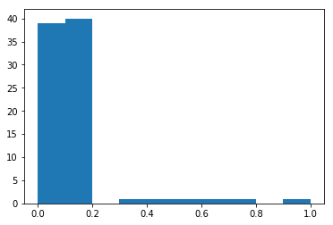

```python
a = plt.hist(percent_missing)
```

We see that of columns with data missing, most of the columns have less than .2 (20%) missing. So let's make 20% the cutoff and remove all columns with a greater percentage of data missing. Let's look at which columns we will drop:

```python
# Remove the outlier columns from the dataset. (You'll perform other data
# engineering tasks such as re-encoding and imputation later.)
remove_columns = percent_missing[percent_missing>0.2]
remove_columns
```

```
TITEL_KZ        0.997576
AGER_TYP        0.769554
KK_KUNDENTYP    0.655967
KBA05_BAUMAX    0.534687
GEBURTSJAHR     0.440203
ALTER_HH        0.348137
dtype: float64
```

#### Discussion 1.1.2: Assess Missing Data

So far, we have identified the columns with the most missing data. We decided to make the cutoff of 20% data, so columns with more than 20% missing will be dropped.

#### Missing data patterns

We see that the columns without any missing data relate to person / personality traits. The data with 10% - 20% missing is shows a certain pattern since the missing percentages are clustered. The clustered percentages are data fields that relate to region and housing. It is possible that this dataset was enriched by the regional / housing data, each of which was missing some of the people in our azdias dataset. These regional / housing columns represent most of the columns between 10% and 20%. However, there is also a column about likelihood to have children in the household, and at the low end, a few columns that reflect personal traits.

#### Columns that will be dropped

So we are dropping a total of six columns. Before we do that, let's take a look at what those columns represent. Looking at the informational file that came with the data set, we see that:

TITEL_KZ is a designation of academic title

AGER_TYP designates the type of ager, with the following classifications: Best-ager typology

- -1: unknown
- 0: no classification possible
- 1: passive elderly
- 2: cultural elderly
- 3: experience-driven elderly

KK_KUNDENTYP is a categorization of consumer habits. Consumer pattern over past 12 months

- -1: unknown
- 1: regular customer
- 2: active customer
- 3: new costumer
- 4: stray customer
- 5: inactive customer
- 6: passive customer

KBA05_BAUMAX refers to the most common building type in the neighborhood (how many families per home)

GEBURTSJAHR gives the birth year. Because there are other features that estimate age (ALTERSKATEGORIE_GROB for example), this one adds little extra information.

ALTER_HH gives the birthdate for the head of the household

With the exception of KBA05_BAUMAX, these columns mostly refer to personal data. While these columns do contain data relevant to the purposes of this project, there is not enough data to make them useful right now, so we will drop them.

```python
azdias = azdias.drop(labels=remove_columns.keys(), axis=1)
azdias.shape
```

```
(891221, 79)
```

#### Step 1.1.3: Assess Missing Data in Each Row

Now, we perform a similar assessment for the rows of the dataset. How much data is missing in each row? We divide the data into two subsets: one for data points that are above some threshold for missing values, and a second subset for points below that threshold.

In order to know what to do with the outlier rows, we should see if the distribution of data values on columns that are not missing data (or are missing very little data) are similar or different between the two groups. Select at least five of these columns and compare the distribution of values.

Depending on what we observe in this comparison, this will have implications on how we approach the conclusions later in the analysis. If the distributions of non-missing features look similar between the data with many missing values and the data with few or no missing values, then we could argue that simply dropping those points from the analysis won't present a major issue. On the other hand, if the data with many missing values looks very different from the data with few or no missing values, then we should make a note of this, possibly to revisit later on.

```python
# How much data is missing in each row of the dataset?
azdias['nan_percent'] = azdias.isnull().mean(axis=1)
azdias['nan_percent'].head()
```

```
0    0.544304
1    0.000000
2    0.000000
3    0.088608
4    0.000000
Name: nan_percent, dtype: float64
```

Above, we have computed the percent of missing data for each row, and recorded it into the dataframe. We can visualize the distribution with a histogram:

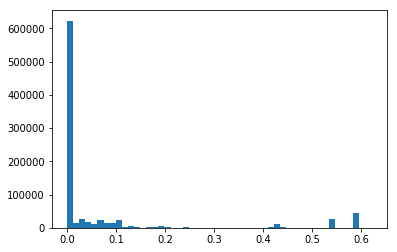

```python
a = plt.hist(azdias['nan_percent'], bins=50)
```

From this histogram, we can see that the majority of the rows have lss than 0.1 (10%) of their data missing. So, now we will divide the dataset into two subsets with 10% as the cutoff.

```python
# Write code to divide the data into two subsets based on the number of missing
# values in each row.
azdias_high = azdias[azdias.nan_percent > 0.1]
azdias_low = azdias[azdias.nan_percent <= 0.1]
```

Now we can examine the distribution of some columns between the two datasets. We will make histograms for 5 columns with no missing values between both sets.

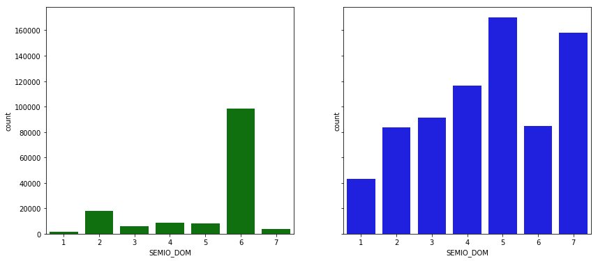

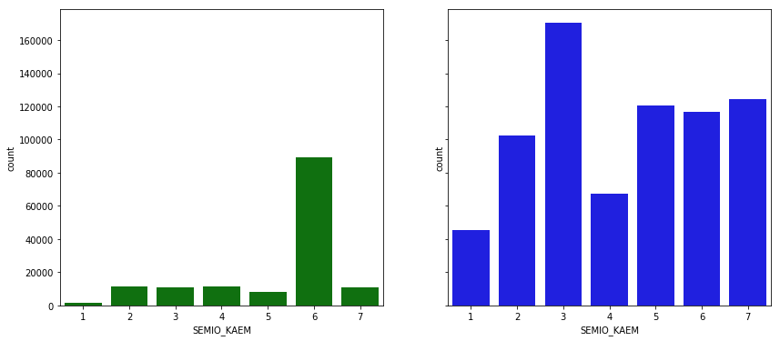

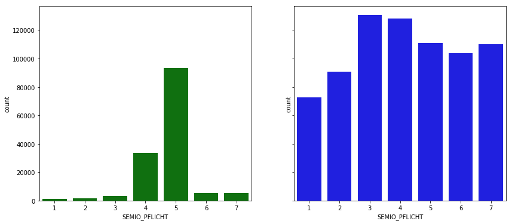

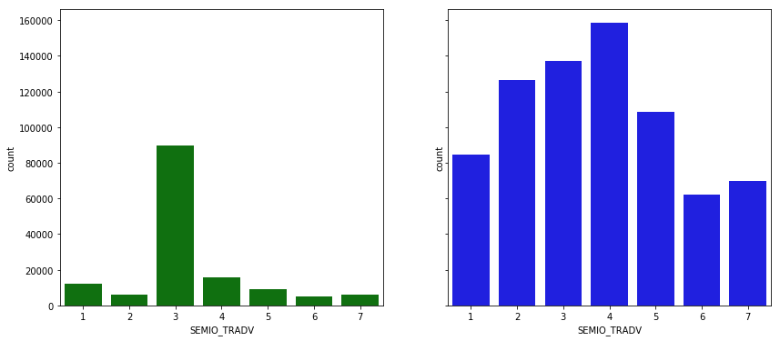

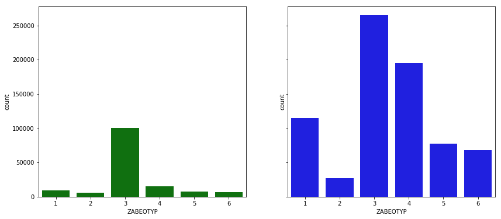

```python
# Compare the distribution of values for at least five columns where there are
# no or few missing values, between the two subsets.
for col in percent_missing.tail().keys():
    fig, axes = plt.subplots(1,2, figsize=(14, 6), sharey=True)
    sns.countplot(azdias_high[col], ax=axes[0], color = 'g')
    sns.countplot(azdias_low[col], ax=axes[1], color = 'b')
```

#### Discussion 1.1.3: Assess Missing Data in Each Row

The distribution of data (shown above) for rows with more than 10% missing data is quite distinct from the distribution shown for rows with less than 10% missing data. There could be many reasons that the data is missing, and these different distributions show that potentially valuable information is lost when discarding the rows with more than 10% of the data missing. However, this loss must be weighed against the risk of including many very incomplete data rows, which might negatively impact the performance of our model.

The data with more than 10% missing show some signs of methodological shortcomings in the collection process. The differing distribution is therefore not to be trusted. So we will proceed with only the the rows which have a low percentage of missing data (less than 10%).

```python
azdias = azdias_low.drop(columns='nan_percent')
```

### Step 1.2: Select and Re-Encode Features

Since the unsupervised learning techniques to be used will only work on data that is encoded numerically, we need to make a few encoding changes or additional assumptions to be able to go forward. In addition, while almost all of the values in the dataset are encoded using numbers, not all of them represent numeric values. If we look at the third column of the feature summary (`feat_info`) for a summary of types of measurement, we see:

- For numeric and interval data, these features can be kept without changes.
- Most of the variables in the dataset are ordinal in nature. While ordinal values may technically be non-linear in spacing, we make the simplifying assumption that the ordinal variables can be treated as being interval in nature (that is, kept without any changes).
- Special handling may be necessary for the remaining two variable types: categorical, and 'mixed'.

In the first two parts of this sub-step, we will perform an investigation of the categorical and mixed-type features and make a decision on each of them, whether to keep, drop, or re-encode each. Then, in the last part, we will create a new data frame with only the selected and engineered columns.

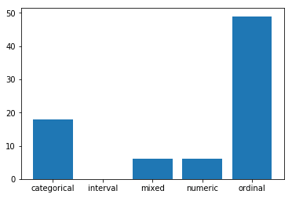

```python
# Count how many features are there of each data type? Save labels for each
feat_info = feat_info[feat_info.attribute.isin(azdias.columns)]
types = ['categorical', 'mixed', 'ordinal', 'numeric', 'interval']
sums = []
labels = []
for x in types:
    sum = feat_info[feat_info.type == x].shape[0]
    sums.append(sum)
    labels.append(feat_info[feat_info.type == x].attribute)
a = plt.bar(x=types, height=sums)
```

#### Step 1.2.1: Re-Encode Categorical Features

For categorical data, it is necessary to encode the levels as dummy variables. Depending on the number of categories, we can perform one of the following:

- For binary (two-level) categoricals that take numeric values, we can keep them without needing to do anything.
- There is one binary variable that takes on non-numeric values. For this one, re-encode the values as numbers.
- For multi-level categoricals (three or more values), we must decide whether to encode them with multiple dummy variables, or to drop them.

```python
# Assess categorical variables: which are binary, which are multi-level, and
# which one needs to be re-encoded?
cat = labels[0]
cat
```

```
2            ANREDE_KZ
3        CJT_GESAMTTYP
10           FINANZTYP
12     GFK_URLAUBERTYP
13    GREEN_AVANTGARDE
17     LP_FAMILIE_FEIN
18     LP_FAMILIE_GROB
19      LP_STATUS_FEIN
20      LP_STATUS_GROB
21    NATIONALITAET_KZ
38         SHOPPER_TYP
39             SOHO_KZ
41            VERS_TYP
42            ZABEOTYP
52         GEBAEUDETYP
55         OST_WEST_KZ
57     CAMEO_DEUG_2015
58      CAMEO_DEU_2015
Name: attribute, dtype: object
```

The columns above are categorical. Now let's look how many categories for each column.

```python
# Re-encode categorical variable(s) to be kept in the analysis.
nunique = azdias[cat].nunique()
nunique
```

```
ANREDE_KZ            2
CJT_GESAMTTYP        6
FINANZTYP            6
GFK_URLAUBERTYP     12
GREEN_AVANTGARDE     2
LP_FAMILIE_FEIN     11
LP_FAMILIE_GROB      5
LP_STATUS_FEIN      10
LP_STATUS_GROB       5
NATIONALITAET_KZ     3
SHOPPER_TYP          4
SOHO_KZ              2
VERS_TYP             2
ZABEOTYP             6
GEBAEUDETYP          7
OST_WEST_KZ          2
CAMEO_DEUG_2015      9
CAMEO_DEU_2015      44
dtype: int64
```

```python
#select binary variables
binary = nunique.loc[nunique == 2]
binary
```

```
ANREDE_KZ           2
GREEN_AVANTGARDE    2
SOHO_KZ             2
VERS_TYP            2
OST_WEST_KZ         2
dtype: int64
```

We see that there are a number of binary columns. Let's look to check that data types to see if they are numerically encoded.

```python
azdias[binary.keys()].head()
```

|  | ANREDE_KZ | GREEN_AVANTGARDE | SOHO_KZ | VERS_TYP | OST_WEST_KZ |
| --- | --- | --- | --- | --- | --- |
| 1 | 2 | 0 | 1.0 | 2.0 | W |
| 2 | 2 | 1 | 0.0 | 1.0 | W |
| 3 | 2 | 0 | 0.0 | 1.0 | W |
| 4 | 1 | 0 | 0.0 | 2.0 | W |
| 5 | 2 | 0 | 0.0 | 2.0 | W |

We want our binary columns all to be with 0 and 1, so let's convert them programmatically.

```python
for x in binary.keys():
    col = azdias[x]
    u = col.unique()
    u.sort()
    d = dict(zip(u, [0,1]))
    col = col.replace(to_replace=d)
    col = pd.to_numeric(col, downcast='integer')
    azdias[x] = col
azdias[binary.keys()].head()
```

|  | ANREDE_KZ | GREEN_AVANTGARDE | SOHO_KZ | VERS_TYP | OST_WEST_KZ |
| --- | --- | --- | --- | --- | --- |
| 1 | 1 | 0 | 1 | 1.0 | 1 |
| 2 | 1 | 1 | 0 | 0.0 | 1 |
| 3 | 1 | 0 | 0 | 0.0 | 1 |
| 4 | 0 | 0 | 0 | 1.0 | 1 |
| 5 | 1 | 0 | 0 | 1.0 | 1 |

For non-binary categorical columns, we need to separate them into dummy variables, each with a column. This is best achieved with the pandas get_dummies() encoder. We will do this for all the columns that have more than 2 unique values (non-binary).

```python
higher_order = nunique.loc[nunique > 2]
higher_order
```

```
CJT_GESAMTTYP        6
FINANZTYP            6
GFK_URLAUBERTYP     12
LP_FAMILIE_FEIN     11
LP_FAMILIE_GROB      5
LP_STATUS_FEIN      10
LP_STATUS_GROB       5
NATIONALITAET_KZ     3
SHOPPER_TYP          4
ZABEOTYP             6
GEBAEUDETYP          7
CAMEO_DEUG_2015      9
CAMEO_DEU_2015      44
dtype: int64
```

```python
cols = higher_order.keys()
azdias = pd.get_dummies(azdias, columns=cols)
azdias.head()
```

|  | ALTERSKATEGORIE_GROB | ANREDE_KZ | FINANZ_MINIMALIST | FINANZ_SPARER | FINANZ_VORSORGER | FINANZ_ANLEGER | FINANZ_UNAUFFAELLIGER | FINANZ_HAUSBAUER | GREEN_AVANTGARDE | HEALTH_TYP | ... | CAMEO_DEU_2015_7E | CAMEO_DEU_2015_8A | CAMEO_DEU_2015_8B | CAMEO_DEU_2015_8C | CAMEO_DEU_2015_8D | CAMEO_DEU_2015_9A | CAMEO_DEU_2015_9B | CAMEO_DEU_2015_9C | CAMEO_DEU_2015_9D | CAMEO_DEU_2015_9E |
| --- | --- | --- | --- | --- | --- | --- | --- | --- | --- | --- | --- | --- | --- | --- | --- | --- | --- | --- | --- | --- | --- |
| 1 | 1.0 | 1 | 1 | 5 | 2 | 5 | 4 | 5 | 0 | 3.0 | ... | 0 | 1 | 0 | 0 | 0 | 0 | 0 | 0 | 0 | 0 |
| 2 | 3.0 | 1 | 1 | 4 | 1 | 2 | 3 | 5 | 1 | 3.0 | ... | 0 | 0 | 0 | 0 | 0 | 0 | 0 | 0 | 0 | 0 |
| 3 | 4.0 | 1 | 4 | 2 | 5 | 2 | 1 | 2 | 0 | 2.0 | ... | 0 | 0 | 0 | 0 | 0 | 0 | 0 | 0 | 0 | 0 |
| 4 | 3.0 | 0 | 4 | 3 | 4 | 1 | 3 | 2 | 0 | 3.0 | ... | 0 | 0 | 0 | 0 | 0 | 0 | 0 | 0 | 0 | 0 |
| 5 | 1.0 | 1 | 3 | 1 | 5 | 2 | 2 | 5 | 0 | 3.0 | ... | 0 | 0 | 0 | 1 | 0 | 0 | 0 | 0 | 0 | 0 |

5 rows × 194 columns

```python
azdias.shape
```

```
(747109, 194)
```

#### Discussion 1.2.1: Re-Encode Categorical Features

For categorical features, it made sense to keep all of the data in the form of dummy variable columns with 0's and 1's. This results in a lot of columns (194), but we will use feature reduction methods subsequently to reduce these.

#### Step 1.2.2: Engineer Mixed-Type Features

There are a handful of features that are marked as "mixed" in the feature summary that require special treatment in order to be included in the analysis. There are two in particular that deserve attention:

- "PRAEGENDE_JUGENDJAHRE" combines information on three dimensions: generation by decade, movement (mainstream vs. avantgarde), and nation (east vs. west). While there aren't enough levels to disentangle east from west, we should create two new variables to capture the other two dimensions: an interval-type variable for decade, and a binary variable for movement.
- "CAMEO_INTL_2015" combines information on two axes: wealth and life stage. We break up the two-digit codes by their 'tens'-place and 'ones'-place digits into two new ordinal variables (which, for the purposes of this project, is equivalent to just treating them as their raw numeric values).

Now let's list the mixed type columns. They are

```python
feat_info[feat_info.type == 'mixed']
```

|  | attribute | information_level | type | missing_or_unknown |
| --- | --- | --- | --- | --- |
| 15 | LP_LEBENSPHASE_FEIN | person | mixed | [0] |
| 16 | LP_LEBENSPHASE_GROB | person | mixed | [0] |
| 22 | PRAEGENDE_JUGENDJAHRE | person | mixed | [-1,0] |
| 56 | WOHNLAGE | building | mixed | [-1] |
| 59 | CAMEO_INTL_2015 | microcell_rr4 | mixed | [-1,XX] |
| 79 | PLZ8_BAUMAX | macrocell_plz8 | mixed | [-1,0] |

First, we can see from the data dictionary that PRAEGENDE_JUGENDJAHRE is a mix of three potential features: generation, movement, and east/west.

### 1.18. PRAEGENDE_JUGENDJAHRE

Dominating movement of person's youth (avantgarde vs. mainstream; east vs. west)

- -1: unknown
- 0: unknown
- 1: 40s - war years (Mainstream, E+W)
- 2: 40s - reconstruction years (Avantgarde, E+W)
- 3: 50s - economic miracle (Mainstream, E+W)
- 4: 50s - milk bar / Individualisation (Avantgarde, E+W)
- 5: 60s - economic miracle (Mainstream, E+W)
- 6: 60s - generation 68 / student protestors (Avantgarde, W)
- 7: 60s - opponents to the building of the Wall (Avantgarde, E)
- 8: 70s - family orientation (Mainstream, E+W)
- 9: 70s - peace movement (Avantgarde, E+W)
- 10: 80s - Generation Golf (Mainstream, W)
- 11: 80s - ecological awareness (Avantgarde, W)
- 12: 80s - FDJ / communist party youth organisation (Mainstream, E)
- 13: 80s - Swords into ploughshares (Avantgarde, E)
- 14: 90s - digital media kids (Mainstream, E+W)
- 15: 90s - ecological awareness (Avantgarde, E+W)

Let's take a look at the distribution in the dataset:

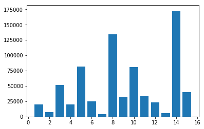

```python
# plt.bar(x=azdias['PRAEGENDE_JUGENDJAHRE'].unique(), height=)
# a = plt.bar(x=types, height=sums)
keys = azdias['PRAEGENDE_JUGENDJAHRE'].value_counts().keys()
vals = azdias['PRAEGENDE_JUGENDJAHRE'].value_counts()
a = plt.bar(x=keys, height=vals)
```

Since east/west last doesn't have enough levels to disentangle, we can make new columns for the decade and movement. We will make a column with integer for decade and a binary column for movement, which we will put 1 for avantgarde and 0 for mainstream.

For decades, we have 40's, 50's, 60's, 70's, 80's, 90's which we will represent with the digits 1 to 6.

For movement, we have avantgarde vs mainstream, and we will put 0 for mainstream and 1 for avantgarde.

```python
decade_dict = {1: 1, 2: 1, 3: 2, 4: 2, 5: 3, 6: 3, 7:  3,
            8: 4, 9: 4, 10: 5, 11: 5, 12: 5, 13: 5, 14: 6, 15: 6}
movement_dict = {1: 0, 3: 0, 5: 0, 8: 0, 10: 0, 12: 0, 14: 0,
                2: 1, 4: 1, 6: 1, 7: 1, 9: 1, 11: 1, 13: 1, 15: 1}

azdias['PRAEGENDE_JUNGENDJAHRE_DECADE'] = azdias['PRAEGENDE_JUGENDJAHRE'].map(decade_dict)
azdias['PRAEGENDE_JUNGENDJAHRE_MOVEMENT'] = azdias['PRAEGENDE_JUGENDJAHRE'].map(movement_dict)
azdias = azdias.drop(columns='PRAEGENDE_JUGENDJAHRE')
azdias.shape
```

```
(747109, 195)
```

Let's take a look at the breakdown of the new columns, first for decades and then for movement

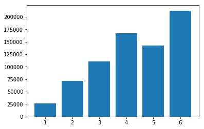

```python
a = plt.bar( x=azdias['PRAEGENDE_JUNGENDJAHRE_DECADE'].value_counts().keys(), height=azdias['PRAEGENDE_JUNGENDJAHRE_DECADE'].value_counts())
```

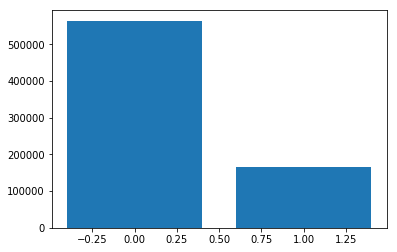

```python
a = plt.bar(x=azdias['PRAEGENDE_JUNGENDJAHRE_MOVEMENT'].value_counts().keys(), height=azdias['PRAEGENDE_JUNGENDJAHRE_MOVEMENT'].value_counts())
```

From the charts above, we see that the largest representation for decade are people from the 90's, and that the majority of people belong to the mainstream movement.

Similarly, CAMEO_INTL_2015 is of mixed type. We have from our data dictionary the following breakdown:

### CAMEO_INTL_2015

German CAMEO: Wealth / Life Stage Typology, mapped to international code

- -1: unknown
- 11: Wealthy Households - Pre-Family Couples & Singles
- 12: Wealthy Households - Young Couples With Children
- 13: Wealthy Households - Families With School Age Children
- 14: Wealthy Households - Older Families & Mature Couples
- 15: Wealthy Households - Elders In Retirement
- 21: Prosperous Households - Pre-Family Couples & Singles
- 22: Prosperous Households - Young Couples With Children
- 23: Prosperous Households - Families With School Age Children
- 24: Prosperous Households - Older Families & Mature Couples
- 25: Prosperous Households - Elders In Retirement
- 31: Comfortable Households - Pre-Family Couples & Singles
- 32: Comfortable Households - Young Couples With Children
- 33: Comfortable Households - Families With School Age Children
- 34: Comfortable Households - Older Families & Mature Couples
- 35: Comfortable Households - Elders In Retirement
- 41: Less Affluent Households - Pre-Family Couples & Singles
- 42: Less Affluent Households - Young Couples With Children
- 43: Less Affluent Households - Families With School Age Children
- 44: Less Affluent Households - Older Families & Mature Couples
- 45: Less Affluent Households - Elders In Retirement
- 51: Poorer Households - Pre-Family Couples & Singles
- 52: Poorer Households - Young Couples With Children
- 53: Poorer Households - Families With School Age Children
- 54: Poorer Households - Older Families & Mature Couples
- 55: Poorer Households - Elders In Retirement
- XX: unknown

We see clearly two dimensions in these specifications, and this is also represented by the number code: the first digit represents wealth and the second represents life stage. So let's separate this data into two columns, with the following codes:

CAMEO_INTL_2015_WEALTH:

Household wealth

1: Wealthy 2: Prosperous 3: Comfortable 4: Less Affluent 5: Poorer

CAMEO_INTL_2015_STAGE:

Life Stage

1: Pre-Family Couples & Singles 2: Young Couples With Children 3: Families With School Age Children 4: Older Families & Mature Couples 5: Elders In Retirement

If we take a peak into the dataset, we can see the number codes represented

```python
azdias['CAMEO_INTL_2015'].head()
```

```
1    51
2    24
3    12
4    43
5    54
Name: CAMEO_INTL_2015, dtype: object
```

```python
#helper method to separate the digits
def digitize(x, digit):
    if not pd.isna(x):
        return int(str(x)[digit])
    return x

azdias['CAMEO_INTL_2015_WEALTH'] = azdias['CAMEO_INTL_2015'].apply(digitize, digit=0)
azdias['CAMEO_INTL_2015_STAGE'] = azdias['CAMEO_INTL_2015'].apply(digitize, digit=1)
azdias = azdias.drop(columns='CAMEO_INTL_2015')
```

Let's take a look at the breakdown of data in these two features with a chart for the count (wealth and life stage):

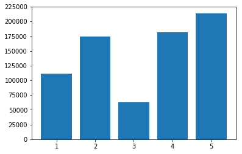

```python
a = plt.bar(x=azdias['CAMEO_INTL_2015_WEALTH'].value_counts().keys(), height=azdias['CAMEO_INTL_2015_WEALTH'].value_counts())
```

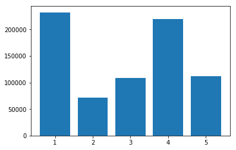

```python
a = plt.bar(x=azdias['CAMEO_INTL_2015_STAGE'].value_counts().keys(), height=azdias['CAMEO_INTL_2015_STAGE'].value_counts())
```

From these breakdowns, we see that there is a reasonable spread of income levels, with the lower two income brackets having the most people. From the life stage, we see that pre-family and older families/mature couples are most represented.

#### Discussion 1.2.2: Engineer Mixed-Type Features

For the CAMEO_INTL_2015 and PRAEGENDE_JUGENDJAHRE columns, we have separated the dimensions in the data and engineered new features (see analysis and feature engineering steps above).

There are still several mixed feature columns:

LP_LEBENSPHASE_GROB and LP_LEBENSPHASE_FEIN are two different resolutions of data about the life phase and income of the individual. Since we have already captured similar data with the features engineered from PRAEGENDE_JUGENDJAHRE and CAMEO_INTL_2015, we will discard these.

WOHNLAGE and PLZ8_BAUMAX refer to the neighborhood and type of building where the person lives. We will discard this data for now, because the way it is broken down is not likely to add useful information to what we already have.

```python
azdias = azdias.drop(columns=['LP_LEBENSPHASE_GROB', 'LP_LEBENSPHASE_FEIN', 'WOHNLAGE', 'PLZ8_BAUMAX'])
azdias.shape
```

```
(747109, 192)
```

#### Step 1.2.3: Complete Feature Selection

In order to finish this step, we need to make sure that the data frame now only has the columns that we want to keep. To summarize, the dataframe should consist of the following:

- All numeric, interval, and ordinal type columns from the original dataset.
- Binary categorical features (all numerically-encoded).
- Engineered features from other multi-level categorical features and mixed features.

```python
# Check that we have all numeric encoded data
g = azdias.columns.to_series().groupby(azdias.dtypes).groups
for key in g.keys():
    print(f'There are {len(g[key])} columns with type {key}')
```

```
There are 4 columns with type int8
There are 128 columns with type uint8
There are 20 columns with type int64
There are 40 columns with type float64
```

### Step 1.3: Create a Cleaning Function

Even though we've finished cleaning up the general population demographics data, it's important to look ahead to the future and realize that we'll need to perform the same cleaning steps on the customer demographics data. In this substep, we make a and test a function to execute the main feature selection, encoding, and re-engineering steps as performed above. Then, when it comes to looking at the customer data in Step 3, we can just run this function on that DataFrame to get the trimmed dataset in a single step.

```python
#convert missing value to nans
def process_nans(df):
    feat_info = pd.read_csv('AZDIAS_Feature_Summary.csv', sep=';')
    nans = [np.nan, np.nan, np.nan, np.nan]
    for i in range(df.shape[1]):
        nan_list = feat_info['missing_or_unknown'][i][1:-1]
        nan_list = nan_list.split(',')
        nan_list = [make_int(x) for x in nan_list]
        nan_dict = dict(zip(nan_list, nans))
        column_name = df.columns[i]
        df[column_name].replace(inplace=True, to_replace=nan_dict)
    return df

#remove columns with more than 20% data missing
def remove_cols(df):
    df = df.drop(labels=remove_columns.keys(), axis=1)
    return df

#remove rows with more than 10% data missing
def remove_rows(df):
    df['nan_percent'] = df.isnull().mean(axis=1)
    df = df[df.nan_percent <= 0.1]
    df = df.drop(columns='nan_percent')
    return df

#return categoricals
def find_cats(df):
    feat_info = pd.read_csv('AZDIAS_Feature_Summary.csv', sep=';')
    feat_info = feat_info[feat_info.attribute.isin(df.columns)]
    labels = []
    for x in types:
        labels.append(feat_info[feat_info.type == x].attribute)
    return labels[0]

#process binaries into 0 and 1
def process_binaries(df, cat):
    nunique = df[cat].nunique()
    binary = nunique.loc[nunique == 2]
    for x in binary.keys():
        col = df[x]
        u = col.unique()
        u.sort()
        d = dict(zip(u, [0,1]))
        col = col.replace(to_replace=d)
        col = pd.to_numeric(col, downcast='integer')
        df[x] = col
    return df

#split mixed features into separate dimensions
def engineer_features(df):
    decade_dict = {1: 1, 2: 1, 3: 2, 4: 2, 5: 3, 6: 3, 7:  3,
            8: 4, 9: 4, 10: 5, 11: 5, 12: 5, 13: 5, 14: 6, 15: 6}
    movement_dict = {1: 0, 3: 0, 5: 0, 8: 0, 10: 0, 12: 0, 14: 0,
                2: 1, 4: 1, 6: 1, 7: 1, 9: 1, 11: 1, 13: 1, 15: 1}

    df['PRAEGENDE_JUNGENDJAHRE_DECADE'] = df['PRAEGENDE_JUGENDJAHRE'].map(decade_dict)
    df['PRAEGENDE_JUNGENDJAHRE_MOVEMENT'] = df['PRAEGENDE_JUGENDJAHRE'].map(movement_dict)
    df = df.drop(columns='PRAEGENDE_JUGENDJAHRE')

    df['CAMEO_INTL_2015_WEALTH'] = df['CAMEO_INTL_2015'].apply(digitize, digit=0)
    df['CAMEO_INTL_2015_STAGE'] = df['CAMEO_INTL_2015'].apply(digitize, digit=1)
    df = df.drop(columns='CAMEO_INTL_2015')

    df = df.drop(columns=['LP_LEBENSPHASE_GROB', 'LP_LEBENSPHASE_FEIN', 'WOHNLAGE', 'PLZ8_BAUMAX'])
    return df

#split higher order categoricals into dummy columns
def create_dummies(df, cat):
    nunique = df[cat].nunique()
    higher_order = nunique.loc[nunique > 2]
    cols = higher_order.keys()
    df = pd.get_dummies(df, columns=cols)
    return df


def clean_data(df):
    """
    Perform feature trimming, re-encoding, and engineering for demographics
    data

    INPUT: Demographics DataFrame
    OUTPUT: Trimmed and cleaned demographics DataFrame
    """

    # Put in code here to execute all main cleaning steps:
    # convert missing value codes into NaNs, ...
    df = process_nans(df)

    # remove selected columns and rows, ...
    df = remove_cols(df)
    df = remove_rows(df)

    # select, re-encode, and engineer column values.
    cat = find_cats(df)
    df = process_binaries(df, cat)
    df = create_dummies(df, cat)
    df = engineer_features(df)

    # Return the cleaned dataframe.
    return df
```

```python
def test_data(azdias):
    print('Working - this might take a minute...')
    df_test = pd.read_csv('Udacity_AZDIAS_Subset.csv', delimiter=';')
    pd.testing.assert_frame_equal(clean_data(df_test), azdias)
    print('Test Passed!')

test_data(azdias)
```

```
Working - this might take a minute...
Test Passed!
```

## Step 2: Feature Transformation

### Step 2.1: Apply Feature Scaling

Before we apply dimensionality reduction techniques to the data, we need to perform feature scaling so that the principal component vectors are not influenced by the natural differences in scale for features. Feature scaling requires no NaN's.

We have separately already removed columns with more than 20% missing and rows with more than 10% missing data. Now let's first check what percentage of the remaining rows have data missing.

```python
nan_percent = azdias.isnull().mean(axis=1)
num_missing = nan_percent[nan_percent > 0].shape[0]
total = azdias.shape[0]
print(f'There are {num_missing} rows missing out of a total of {total}. This reflects {round(num_missing*100/total)}%')
```

```
There are 123898 rows missing out of a total of 747109. This reflects 17%
```

While 17% is a significant number of rows with missing data, let's take a look at how many individual nans in total out of all the values in our data set. This will give us an idea whether to discard the rows or impute values for the missing data. In order to do this, we use the number of columns in the original data set minus the columns that were completely dropped (otherwise our dummy variable columns would skew the result).

```python
nan_count = azdias.isnull().sum().sum()
total_count = 75 * azdias.shape[0]
print(f'There are {nan_count} NaNs out of a total of {total_count} data fields, which is {nan_count/total_count *100}%')
```

```
There are 320763 NaNs out of a total of 56033175 data fields, which is 0.57245194476308%
```

This is indeed a rather small percentage of missing data, versus the 17% data that would be discarded if we simply though out all rows with NaN's. So let's use the imputer with a mean value to fill in the gaps so we can use all rows.

```python
imputer = Imputer(missing_values='NaN', strategy='mean', axis=0)
vals = imputer.fit_transform(azdias)
```

```python
scaler = StandardScaler()
scaled = scaler.fit_transform(vals)
scaled = pd.DataFrame(scaled, columns=azdias.columns)
scaled.head()
```

|  | ALTERSKATEGORIE_GROB | ANREDE_KZ | FINANZ_MINIMALIST | FINANZ_SPARER | FINANZ_VORSORGER | FINANZ_ANLEGER | FINANZ_UNAUFFAELLIGER | FINANZ_HAUSBAUER | GREEN_AVANTGARDE | HEALTH_TYP | ... | CAMEO_DEU_2015_8D | CAMEO_DEU_2015_9A | CAMEO_DEU_2015_9B | CAMEO_DEU_2015_9C | CAMEO_DEU_2015_9D | CAMEO_DEU_2015_9E | PRAEGENDE_JUNGENDJAHRE_DECADE | PRAEGENDE_JUNGENDJAHRE_MOVEMENT | CAMEO_INTL_2015_WEALTH | CAMEO_INTL_2015_STAGE |
| --- | --- | --- | --- | --- | --- | --- | --- | --- | --- | --- | --- | --- | --- | --- | --- | --- | --- | --- | --- | --- | --- |
| 0 | -1.754375 | 0.962859 | -1.503661 | 1.559941 | -1.049535 | 1.490708 | 1.013168 | 1.331159 | -0.536372 | 1.065804 | ... | -0.152876 | -0.164254 | -0.19162 | -0.180623 | -0.195966 | -0.087052 | 1.164694 | -0.549948 | 1.173102 | -1.259383 |
| 1 | 0.198908 | 0.962859 | -1.503661 | 0.884836 | -1.773085 | -0.555630 | 0.291141 | 1.331159 | 1.864378 | 1.065804 | ... | -0.152876 | -0.164254 | -0.19162 | -0.180623 | -0.195966 | -0.087052 | 1.164694 | 1.858454 | -0.877743 | 0.756001 |
| 2 | 1.175549 | 0.962859 | 0.685685 | -0.465374 | 1.121117 | -0.555630 | -1.152912 | -0.831846 | -0.536372 | -0.280182 | ... | -0.152876 | -0.164254 | -0.19162 | -0.180623 | -0.195966 | -0.087052 | -0.219810 | -0.549948 | -1.561358 | -0.587588 |
| 3 | 0.198908 | -1.038573 | 0.685685 | 0.209731 | 0.397566 | -1.237743 | 0.291141 | -0.831846 | -0.536372 | 1.065804 | ... | -0.152876 | -0.164254 | -0.19162 | -0.180623 | -0.195966 | -0.087052 | -0.219810 | -0.549948 | 0.489487 | 0.084207 |
| 4 | -1.754375 | 0.962859 | -0.044097 | -1.140479 | 1.121117 | -0.555630 | -0.430886 | 1.331159 | -0.536372 | 1.065804 | ... | -0.152876 | -0.164254 | -0.19162 | -0.180623 | -0.195966 | -0.087052 | -1.604315 | -0.549948 | 1.173102 | 0.756001 |

5 rows × 192 columns

Let's check to make sure there are no NaN's left:

```python
print(f'there are {scaled.isnull().sum().sum()} NaNs in scaled')
```

```
there are 0 NaNs in scaled
```

### Discussion 2.1: Apply Feature Scaling

In examining the missing data, we found that even though 17% of rows had missing data, there were not really so many pieces of data missing as a percentage of the whole (less than 1% of the remaining data). So it made sense to use imputation to salvage the rows with missing data.

To do this, we used imputation with the mean value.

For scaling, it made most sense to go with the standard scaler. At this point, our dataset has no NaN's and is scaled appropriately.

### Step 2.2: Perform Dimensionality Reduction

On your scaled data, we are now ready to apply dimensionality reduction techniques.

- We use sklearn's [PCA](http://scikit-learn.org/stable/modules/generated/sklearn.decomposition.PCA.html) class to apply principal component analysis on the data, thus finding the vectors of maximal variance in the data.
- We examine the ratio of variance explained by each principal component as well as the cumulative variance explained. Based on what the findings, we select a value for the number of transformed features to retain for the clustering part of the project.

```python
# Apply PCA to the data.
pca = PCA()
pca = pca.fit(scaled)
```

```
192
```

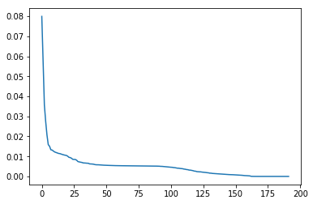

```python
# Investigate the variance accounted for by each principal component.
# indices = range(len(pca.explained_variance_ratio_))
print(pca.n_components_)
a = plt.plot(pca.explained_variance_ratio_)
```

The plot above shows an elbow at about 8 and a flattening at around 27, then another flattening around 125 features. This is hard to see, so here's a focus on the first 30 features:

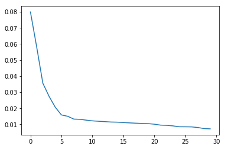

```python
a = plt.plot(pca.explained_variance_ratio_[0:30])
```

Since there is a clear elbow at 8 features, we will refit the PCA to keep 8 features

```python
# Re-apply PCA to the data while selecting for number of components to retain.
pca_b = PCA(n_components = 8)
pca_b.fit(scaled)
```

```
PCA(copy=True, iterated_power='auto', n_components=8, random_state=None,
  svd_solver='auto', tol=0.0, whiten=False)
```

```python
#REFERENCE: The code for the scree plot function below is taken from Udacity's 'helper functions' library
def scree_plot(pca):
    '''
    Creates a scree plot associated with the principal components

    INPUT: pca - the result of instantian of PCA in scikit learn

    OUTPUT:
            None
    '''
    num_components=len(pca.explained_variance_ratio_)
    ind = np.arange(num_components)
    vals = pca.explained_variance_ratio_

    plt.figure(figsize=(10, 6))
    ax = plt.subplot(111)
    cumvals = np.cumsum(vals)
    ax.bar(ind, vals)
    ax.plot(ind, cumvals)
    for i in range(num_components):
        ax.annotate(r"%s%%" % ((str(vals[i]*100)[:4])), (ind[i]+0.2, vals[i]), va="bottom", ha="center", fontsize=12)

    ax.xaxis.set_tick_params(width=0)
    ax.yaxis.set_tick_params(width=2, length=12)

    ax.set_xlabel("Principal Component")
    ax.set_ylabel("Variance Explained (%)")
    plt.title('Explained Variance Per Principal Component')
```

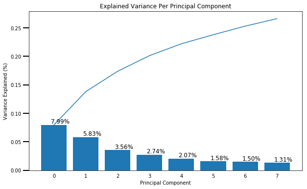

```python
scree_plot(pca_b)
```

```python
var = np.sum(pca_b.explained_variance_ratio_)
var
```

```
0.26617780904867816
```

Because 8 features only explains 27% variance, we need to go back and make a PCA with more features. I had seen a flattening at 27 features, so I will try that now:

```python
pca_c = PCA(n_components = 27)
pca_c.fit(scaled)
```

```
PCA(copy=True, iterated_power='auto', n_components=27, random_state=None,
  svd_solver='auto', tol=0.0, whiten=False)
```

```python
var = np.sum(pca_c.explained_variance_ratio_)
var
```

```
0.46541340247340135
```

So this represents about 46.5% of the variance. It still seems rather low, so now let's try 125 features:

```python
pca_d = PCA(n_components = 125)
pca_d.fit(scaled)
```

```
PCA(copy=True, iterated_power='auto', n_components=125, random_state=None,
  svd_solver='auto', tol=0.0, whiten=False)
```

```python
var = np.sum(pca_d.explained_variance_ratio_)
var
```

```
0.96054472486715414
```

### 2.2.2 Discussion of PCA

In deciding how many components to create using PCA, it is important to weigh two competing factors: how much information from the dataset can we use, and the performance of the kmeans algorithm in higher dimensions. In higher dimensions, the "curse of dimensionality" sets in. However, this is not correlated with a specific number of dimensions. Rather, it occurs based on the actual distribution of data within dimensions. Said in another way, there is no one number as a higher limit for dimensions. It all depends on the dataset itself. Our PCA with 125 dimensions captures most of the information of the data. However, it will be extremely inefficient to use so many dimensions with the kmeans algorithm and the "curse of dimensionality" will certainly set in. The PCA with 8 dimensions captures too little of the information in the dataset. It seems like 27 dimensions, despite only capturing 46.5% of the data, is still an awful lot of dimensions. So ultimately I decided to go with 13 dimensions, which strikes a balance between usage of information and performance for kmeans. So I will create pca_e with 13 dimensions and use it for clustering.

```python
pca_e = PCA(n_components = 13)
pca_e.fit(scaled)
```

```
PCA(copy=True, iterated_power='auto', n_components=13, random_state=None,
  svd_solver='auto', tol=0.0, whiten=False)
```

```python
var = np.sum(pca_e.explained_variance_ratio_)
var
```

```
0.32780599484332751
```

```python
#to experiment with how long it takes kmeans to train, i make all transformations
df_pca_c = pca_c.transform(scaled)
df_pca_d = pca_d.transform(scaled)
df_pca_b = pca_b.transform(scaled)
df_pca_e = pca_e.transform(scaled)
```

### Step 2.3: Interpret Principal Components

Now that we have our transformed principal components, it's a nice idea to check out the weight of each variable on the first few components to see if they can be interpreted in some fashion.

As a reminder, each principal component is a unit vector that points in the direction of highest variance (after accounting for the variance captured by earlier principal components). The further a weight is from zero, the more the principal component is in the direction of the corresponding feature. If two features have large weights of the same sign (both positive or both negative), then increases in one tend expect to be associated with increases in the other. To contrast, features with different signs can be expected to show a negative correlation: increases in one variable should result in a decrease in the other.

- To investigate the features, we should map each weight to their corresponding feature name, then sort the features according to weight. The most interesting features for each principal component, then, will be those at the beginning and end of the sorted list. We use the data dictionary document to help understand these most prominent features, their relationships, and what a positive or negative value on the principal component might indicate.
- We should investigate and interpret feature associations from the first three or four principal components in this substep. To help facilitate this, we write a function that can be called at any time to print the sorted list of feature weights, for the *i*-th principal component.

```python
def map_pca_weights(pca, df, n_comp):
    weights = pd.DataFrame(np.round(pca.components_, 4), columns=df.keys())
    comp = weights.iloc[n_comp-1, :]
    positive = comp[comp > 0].sort_values(ascending=False)
    negative = comp[comp <= 0].sort_values()
    return positive, negative
```

```python
def list_pos_neg(pos, neg, n_comp):
    print(f'For component {n_comp}, the top positive features are:')
    print(pos[0:10])
    print('')
    print(f'And for component {n_comp} the top negative features are:')
    print(neg[0:10])
```

```python
pos, neg = map_pca_weights(pca_e, scaled, 1)
list_pos_neg(pos, neg, 1)
```

```
For component 1, the top positive features are:
LP_STATUS_GROB_1.0        0.1956
HH_EINKOMMEN_SCORE        0.1853
CAMEO_INTL_2015_WEALTH    0.1851
PLZ8_ANTG3                0.1815
PLZ8_ANTG4                0.1756
ORTSGR_KLS9               0.1529
EWDICHTE                  0.1514
FINANZ_HAUSBAUER          0.1452
LP_STATUS_FEIN_1.0        0.1280
KBA05_ANTG4               0.1273
Name: 0, dtype: float64

And for component 1 the top negative features are:
MOBI_REGIO            -0.2056
FINANZ_MINIMALIST     -0.1927
KBA05_ANTG1           -0.1926
KBA05_GBZ             -0.1826
PLZ8_ANTG1            -0.1826
KONSUMNAEHE           -0.1344
PLZ8_GBZ              -0.1335
INNENSTADT            -0.1259
LP_STATUS_GROB_5.0    -0.1177
LP_STATUS_FEIN_10.0   -0.1177
Name: 0, dtype: float64
```

In both positive and negative cases, the breakdown of the weights show that looking at the top 5 features would give a good insight into this component. So we take a look at the data dictionary, and can draw the following conclusions:

### Component 1 - Positive

LP_STATUS_GROB_1.0 - this is a categorical variable that shows low income earners

HH_EINKOMMEN_SCORE - this data is also associated with income (higher numerical values show lower income)

CAMEO_INTL_2015_WEALTH - this was a feature we engineered from CAMEO_INTL_2015 which shows wealth (higher numerical values show lower income)

PLZ8_ANTG3 - this relates to the share of 6-10 family homes in the region where the person lives, with higher score correlating to a greater share

PLZ8_ANTG4 - this relates to the share of 10+ family homes in the region where the person lives, with higher score relating to greater share

### Component 1 - Negative

MOBI_REGIO - Movement patterns (higher score shows lower movement)

FINANZ_MINIMALIST - Financial minimalism (a higher score shows lower financial minimalism)

KBA05_ANTG1 - number of 1-2 family homes (a higher score shows a high share)

KBA05_GBZ - number of buildings in the microcell (a higher score shows higher number)

PLZ8_ANTG1 - number of 1-2 family homes (a higher score shows a high share)

### Component 1 Discussion

There are two very strong components in feature one, supported by both the positive and negative features.

The first is the financial status / income of the person. This component is oriented towards low income, low wealth and financial minimalism.

The second is the density of housing or population in the area where the person lives. This component shows high density of buildings and larger number of families per building.

So we can summarize this as low income people in high density housing.

```python
# Map weights for the second principal component to corresponding feature names
# and then print the linked values, sorted by weight.
pos, neg = map_pca_weights(pca_e, scaled, 2)
list_pos_neg(pos, neg, 2)
```

```
For component 2, the top positive features are:
ALTERSKATEGORIE_GROB    0.2305
FINANZ_VORSORGER        0.2153
ZABEOTYP_3              0.2001
SEMIO_ERL               0.1804
SEMIO_LUST              0.1614
RETOURTYP_BK_S          0.1581
W_KEIT_KIND_HH          0.1265
CJT_GESAMTTYP_2.0       0.1056
LP_STATUS_FEIN_1.0      0.1010
FINANZTYP_5             0.0963
Name: 1, dtype: float64

And for component 2 the top negative features are:
PRAEGENDE_JUNGENDJAHRE_DECADE   -0.2344
FINANZ_SPARER                   -0.2235
SEMIO_REL                       -0.2143
FINANZ_UNAUFFAELLIGER           -0.2121
SEMIO_TRADV                     -0.2065
SEMIO_PFLICHT                   -0.2045
FINANZ_ANLEGER                  -0.2022
SEMIO_KULT                      -0.1659
SEMIO_RAT                       -0.1658
ONLINE_AFFINITAET               -0.1641
Name: 1, dtype: float64
```

```python
pos, neg = map_pca_weights(pca_e, scaled, 2)
list_pos_neg(pos, neg, 2)
```

```
For component 2, the top positive features are:
ALTERSKATEGORIE_GROB    0.2305
FINANZ_VORSORGER        0.2153
ZABEOTYP_3              0.2001
SEMIO_ERL               0.1804
SEMIO_LUST              0.1614
RETOURTYP_BK_S          0.1581
W_KEIT_KIND_HH          0.1265
CJT_GESAMTTYP_2.0       0.1056
LP_STATUS_FEIN_1.0      0.1010
FINANZTYP_5             0.0963
Name: 1, dtype: float64

And for component 2 the top negative features are:
PRAEGENDE_JUNGENDJAHRE_DECADE   -0.2344
FINANZ_SPARER                   -0.2235
SEMIO_REL                       -0.2143
FINANZ_UNAUFFAELLIGER           -0.2121
SEMIO_TRADV                     -0.2065
SEMIO_PFLICHT                   -0.2045
FINANZ_ANLEGER                  -0.2022
SEMIO_KULT                      -0.1659
SEMIO_RAT                       -0.1658
ONLINE_AFFINITAET               -0.1641
Name: 1, dtype: float64
```

### Component 2 Positive

ALTERSKATEGORIE_GROB - Age (higher is older)

FINANZ_VORSORGER - Financial preparer (higher score means lower financial preparedness)

ZABEOTYP_3 - Fair supplied energy consumer (categorical)

SEMIO_ERL - Event oriented personality (high score means low affinity)

SEMIO_LUST - Sensual personality (high score means low affinity)

RETOURTYP_BK_S - How many returns a customer makes (high score means few returns)

### Component 2 Negative

PRAEGENDE_JUNGENDJAHRE_DECADE - Decade of birth (high number is more recent)

FINANZ_SPARER - Saver (high number is low saving)

SEMIO_REL - Religious (high number is low affinity)

FINANZ_UNAUFFAELLIGER - Financially inconspicuous (high number is low in this typology)

SEMIO_TRADV - Traditional minded (high number is low affinity)

SEMIO_PFLICHT - Dutiful (high number is low affinity)

FINANZ_ANLEGER - Investor (high number is low in this classification)

### Component 2 Discussion

Component two is characterized by a number of traits that seem to possibly be correlated with older age and conservativism:

-- lower financial preparation and financially inconspicuous, but higher rates of saving and investing

-- religious, traditional minded, low affinity for sensuality and events

```python
# Map weights for the third principal component to corresponding feature names
# and then print the linked values, sorted by weight.
pos, neg = map_pca_weights(pca_e, scaled, 3)
list_pos_neg(pos, neg, 3)
```

```
For component 3, the top positive features are:
SEMIO_VERT           0.3204
SEMIO_FAM            0.2603
SEMIO_SOZ            0.2575
SEMIO_KULT           0.2481
FINANZTYP_5          0.1370
FINANZ_MINIMALIST    0.1296
SHOPPER_TYP_0.0      0.1233
SEMIO_REL            0.1166
ZABEOTYP_1           0.1164
SEMIO_MAT            0.0859
Name: 2, dtype: float64

And for component 3 the top negative features are:
ANREDE_KZ            -0.3448
SEMIO_KAEM           -0.3149
SEMIO_DOM            -0.2817
SEMIO_KRIT           -0.2626
SEMIO_ERL            -0.2050
SEMIO_RAT            -0.1550
FINANZ_ANLEGER       -0.1533
FINANZTYP_1          -0.0988
SHOPPER_TYP_2.0      -0.0983
LP_STATUS_FEIN_2.0   -0.0804
Name: 2, dtype: float64
```

### Component 3 Positive

SEMIO_VERT - Dreamer (high score means low affinity)

SEMIO_FAM - Family minded (high score means low affinity)

SEMIO_SOZ - Socially minded (high score means low affinity)

SEMIO_KULT - Cultural minded (high score means low affinity)

FINANZTYP_5 - Investor (categorical)

### Component 3 Negative

ANREDE_KZ - Gender (higher score is more likely to be female)

SEMIO_KAEM - Combative attitude (higher score is lower affinity)

SEMIO_DOM - Dominant minded (higher score is lower affinity)

SEMIO_KRIT - Critical minded (higher score is lower affinity)

SEMIO_ERL - Event oriented (higher score is lower affinity)

SEMIO_RAT - Rational (higher score is a lower affinity)

### Component 3 Discussion

Component 3 centers around a cluster of personality traits:

-male

-down to earth, not particularly socially or family oriented, less interested in culture

-combative, dominant, critical, event oriented and rational

Also, component 3 is associated with being an investor.

```python
pos, neg = map_pca_weights(pca_e, scaled, 4)
list_pos_neg(pos, neg, 4)
```

```
For component 4, the top positive features are:
PRAEGENDE_JUNGENDJAHRE_MOVEMENT    0.2906
GREEN_AVANTGARDE                   0.2899
LP_STATUS_FEIN_10.0                0.2395
LP_STATUS_GROB_5.0                 0.2395
EWDICHTE                           0.2100
ORTSGR_KLS9                        0.2050
ANZ_PERSONEN                       0.1364
SEMIO_DOM                          0.1290
ONLINE_AFFINITAET                  0.1203
SEMIO_KAEM                         0.1183
Name: 3, dtype: float64

And for component 4 the top negative features are:
LP_STATUS_GROB_4.0    -0.1972
LP_STATUS_FEIN_9.0    -0.1869
BALLRAUM              -0.1736
INNENSTADT            -0.1706
HH_EINKOMMEN_SCORE    -0.1616
KKK                   -0.1604
LP_FAMILIE_GROB_1.0   -0.1444
LP_FAMILIE_FEIN_1.0   -0.1444
LP_STATUS_FEIN_4.0    -0.1334
KONSUMNAEHE           -0.1164
Name: 3, dtype: float64
```

### Component 4 Positive

PRAEGENDE_JUNGENDJAHRE_MOVEMENT - Higher value indicates more avant-garde and less mainstream

GREEN_AVANTGARDE - Higher value indicates interest during youth in environmental sustainability

LP_STATUS_FEIN_10.0 - This categorical variable relates to top earners

LP_STATUS_GROB_5.0 - Top earners (categorical)

EWDICHTE - Density of households per km2 (high values indicate higher density)

### Component 4 Negative

LP_STATUS_GROB_4.0 - Homeowners (categorical)

LP_STATUS_FEIN_9.0 - Homeowners (categorical)

BALLRAUM - Distance to nearest urban center (higher means greater distance)

INNENSTADT - Distance to city center (higher means greater distance)

HH_EINKOMMEN_SCORE - Income (higher score means lower income)

KKK - Purchasing power in region (higher score means lower purchasing power)

### Component 4 Discussion

Component 4 indicates:

--higher income, from regions with higher purchasing power, greater representation of top earners

--more avantgarde and more likely to be involved with environmental sustainability

--less likely to be homeowners

## Step 3: Clustering

### Step 3.1: Apply Clustering to General Population

We've assessed and cleaned the demographics data, then scaled and transformed them. Now, it's time to see how the data clusters in the principal components space. In this substep, we will apply k-means clustering to the dataset and use the average within-cluster distances from each point to their assigned cluster's centroid to decide on a number of clusters to keep.

- Use sklearn's KMeans class to perform k-means clustering on the PCA-transformed data.
- Then, compute the average difference from each point to its assigned cluster's center.
- Perform the above two steps for a number of different cluster counts. Then see how the average distance decreases with an increasing number of clusters. However, each additional cluster provides a smaller net benefit. Use this fact to select a final number of clusters in which to group the data.
- Once we've selected a final number of clusters to use, we re-fit a KMeans instance to perform the clustering operation.

```python
scores = {}
for i in range(5,20):
    kmeans = KMeans(n_clusters=i, n_jobs=-1)
    kmeans = kmeans.fit(df_pca_e)
    scores[i] = np.abs(kmeans.score(df_pca_e))
    print(f'Completed {i} with score {scores[i]}')
```

```
Completed 5 with score 29360535.77023995
Completed 6 with score 28009536.029679254
Completed 7 with score 26892040.62002592
Completed 8 with score 25964370.62125579
Completed 9 with score 25116656.939602368
Completed 10 with score 24345912.657562584
Completed 11 with score 23767754.857518997
Completed 12 with score 23213081.332643256
Completed 13 with score 22737058.95577623
Completed 14 with score 22386612.270487648
Completed 15 with score 21891425.49604696
Completed 16 with score 21575252.893535558
Completed 17 with score 21303000.901744224
Completed 18 with score 20938942.662899066
Completed 19 with score 20598915.009102903
```

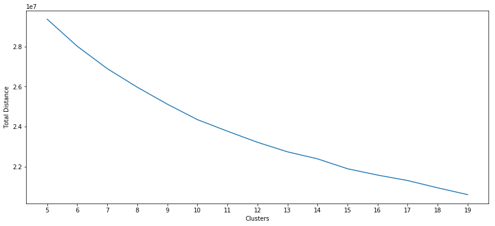

```python
# Investigate the change in within-cluster distance across number of clusters.
# HINT: Use matplotlib's plot function to visualize this relationship.
fig, ax = plt.subplots(figsize=(14,6))
ax = pd.Series(scores).plot()
ax.set_xticks(np.arange(5,20));
ax.set_xlabel("Clusters")
ax.set_ylabel("Total Distance");
```

From the visualization above, it seems that there is a slight elbow at 10, so we will use 10 as our number of clusters.

```python
# Re-fit the k-means model with the selected number of clusters and obtain
# cluster predictions for the general population demographics data.
kmeans = KMeans(n_clusters=10, n_jobs=-1)
kmeans = kmeans.fit(df_pca_e)
```

### Discussion 3.1: Apply Clustering to General Population

We tried many different cluster sizes to find out the cluster size that will give us the most insight in the data. In a line graph of the kmeans scores, we see a slight elbow at 10. The graph reflects the diminishing usefulness of each additional cluster, and we should try to find the smallest number of clusters that fits the data well. The elbow shows a smaller rate of change in the score, and thus is a logical value to choose for the number of clusters. So we go forward with 10 clusters.

### Step 3.2: Apply All Steps to the Customer Data

Now that we have clusters and cluster centers for the general population, it's time to see how the customer data maps on to those clusters.

```python
# Load in the customer demographics data.
customers = pd.read_csv('Udacity_CUSTOMERS_Subset.csv', sep=';')
customers.head()
```

|  | AGER_TYP | ALTERSKATEGORIE_GROB | ANREDE_KZ | CJT_GESAMTTYP | FINANZ_MINIMALIST | FINANZ_SPARER | FINANZ_VORSORGER | FINANZ_ANLEGER | FINANZ_UNAUFFAELLIGER | FINANZ_HAUSBAUER | ... | PLZ8_ANTG1 | PLZ8_ANTG2 | PLZ8_ANTG3 | PLZ8_ANTG4 | PLZ8_BAUMAX | PLZ8_HHZ | PLZ8_GBZ | ARBEIT | ORTSGR_KLS9 | RELAT_AB |
| --- | --- | --- | --- | --- | --- | --- | --- | --- | --- | --- | --- | --- | --- | --- | --- | --- | --- | --- | --- | --- | --- |
| 0 | 2 | 4 | 1 | 5.0 | 5 | 1 | 5 | 1 | 2 | 2 | ... | 3.0 | 3.0 | 1.0 | 0.0 | 1.0 | 5.0 | 5.0 | 1.0 | 2.0 | 1.0 |
| 1 | -1 | 4 | 1 | NaN | 5 | 1 | 5 | 1 | 3 | 2 | ... | NaN | NaN | NaN | NaN | NaN | NaN | NaN | NaN | NaN | NaN |
| 2 | -1 | 4 | 2 | 2.0 | 5 | 1 | 5 | 1 | 4 | 4 | ... | 2.0 | 3.0 | 3.0 | 1.0 | 3.0 | 3.0 | 2.0 | 3.0 | 5.0 | 3.0 |
| 3 | 1 | 4 | 1 | 2.0 | 5 | 1 | 5 | 2 | 1 | 2 | ... | 3.0 | 2.0 | 1.0 | 0.0 | 1.0 | 3.0 | 4.0 | 1.0 | 3.0 | 1.0 |
| 4 | -1 | 3 | 1 | 6.0 | 3 | 1 | 4 | 4 | 5 | 2 | ... | 2.0 | 4.0 | 2.0 | 1.0 | 2.0 | 3.0 | 3.0 | 3.0 | 5.0 | 1.0 |

5 rows × 85 columns

```python
# Apply preprocessing, feature transformation, and clustering from the general
# demographics onto the customer data, obtaining cluster predictions for the
# customer demographics data.
customers = clean_data(customers)
customers.shape
```

```
(133427, 191)
```

```python
customer_cols = list(customers.columns)
azdias_cols = list(azdias.columns)
for col in customers.columns:
    azdias_cols.remove(col)
print(azdias_cols)
```

```
['GEBAEUDETYP_5.0']
```

There is one column fewer for the customers data frame than for the azdias data frame. This is because of the categorical variable one-hot encoding - there was one fewer category represented in the customer data set. This is not a problem. We can see that the column is GEBAEUDETYP_5.0. So we will add this column to customers and fill it with 0's

```python
customers['GEBAEUDETYP_5.0'] = 0
```

```python
customers_imputed = imputer.transform(customers)
```

```python
customers_scaled = scaler.transform(customers_imputed)
customers_scaled = pd.DataFrame(scaled, columns=customers.columns)
customers_scaled.head()
```

|  | ALTERSKATEGORIE_GROB | ANREDE_KZ | FINANZ_MINIMALIST | FINANZ_SPARER | FINANZ_VORSORGER | FINANZ_ANLEGER | FINANZ_UNAUFFAELLIGER | FINANZ_HAUSBAUER | GREEN_AVANTGARDE | HEALTH_TYP | ... | CAMEO_DEU_2015_9A | CAMEO_DEU_2015_9B | CAMEO_DEU_2015_9C | CAMEO_DEU_2015_9D | CAMEO_DEU_2015_9E | PRAEGENDE_JUNGENDJAHRE_DECADE | PRAEGENDE_JUNGENDJAHRE_MOVEMENT | CAMEO_INTL_2015_WEALTH | CAMEO_INTL_2015_STAGE | GEBAEUDETYP_5.0 |
| --- | --- | --- | --- | --- | --- | --- | --- | --- | --- | --- | --- | --- | --- | --- | --- | --- | --- | --- | --- | --- | --- |
| 0 | -1.754375 | 0.962859 | -1.503661 | 1.559941 | -1.049535 | 1.490708 | 1.013168 | 1.331159 | -0.536372 | 1.065804 | ... | -0.164254 | -0.19162 | -0.180623 | -0.195966 | -0.087052 | 1.164694 | -0.549948 | 1.173102 | -1.259383 | -0.001157 |
| 1 | 0.198908 | 0.962859 | -1.503661 | 0.884836 | -1.773085 | -0.555630 | 0.291141 | 1.331159 | 1.864378 | 1.065804 | ... | -0.164254 | -0.19162 | -0.180623 | -0.195966 | -0.087052 | 1.164694 | 1.858454 | -0.877743 | 0.756001 | -0.001157 |
| 2 | 1.175549 | 0.962859 | 0.685685 | -0.465374 | 1.121117 | -0.555630 | -1.152912 | -0.831846 | -0.536372 | -0.280182 | ... | -0.164254 | -0.19162 | -0.180623 | -0.195966 | -0.087052 | -0.219810 | -0.549948 | -1.561358 | -0.587588 | -0.001157 |
| 3 | 0.198908 | -1.038573 | 0.685685 | 0.209731 | 0.397566 | -1.237743 | 0.291141 | -0.831846 | -0.536372 | 1.065804 | ... | -0.164254 | -0.19162 | -0.180623 | -0.195966 | -0.087052 | -0.219810 | -0.549948 | 0.489487 | 0.084207 | -0.001157 |
| 4 | -1.754375 | 0.962859 | -0.044097 | -1.140479 | 1.121117 | -0.555630 | -0.430886 | 1.331159 | -0.536372 | 1.065804 | ... | -0.164254 | -0.19162 | -0.180623 | -0.195966 | -0.087052 | -1.604315 | -0.549948 | 1.173102 | 0.756001 | -0.001157 |

5 rows × 192 columns

```python
customers_pca = pca_e.transform(customers_scaled)
customers_pca.shape
```

```
(747109, 13)
```

```python
cust_labels = kmeans.predict(customers_pca)
```

```python
cust_unique = np.unique(cust_labels, return_counts=True)
cust_unique
```

```
(array([0, 1, 2, 3, 4, 5, 6, 7, 8, 9], dtype=int32),
 array([ 58897,  74426,  61181,  81613,  74502, 105600,  30576,  80852,
         99459,  80003]))
```

### Step 3.3: Compare Customer Data to Demographics Data

At this point, we have clustered data based on demographics of the general population of Germany, and seen how the customer data for a mail-order sales company maps onto those demographic clusters. In this final substep, we will compare the two cluster distributions to see where the strongest customer base for the company is.

We consider the proportion of persons in each cluster for the general population, and the proportions for the customers. If we think the company's customer base to be universal, then the cluster assignment proportions should be fairly similar between the two. If there are only particular segments of the population that are interested in the company's products, then we should see a mismatch from one to the other. If there is a higher proportion of persons in a cluster for the customer data compared to the general population (e.g. 5% of persons are assigned to a cluster for the general population, but 15% of the customer data is closest to that cluster's centroid) then that suggests the people in that cluster to be a target audience for the company. On the other hand, the proportion of the data in a cluster being larger in the general population than the customer data (e.g. only 2% of customers closest to a population centroid that captures 6% of the data) suggests that group of persons to be outside of the target demographics.

```python
# Compare the proportion of data in each cluster for the customer data to the
# proportion of data in each cluster for the general population.
pop_labels = kmeans.labels_
len(pop_labels)
```

```
747109
```

```python
pop_unique = np.unique(pop_labels, return_counts=True)
pop_unique
```

```
(array([0, 1, 2, 3, 4, 5, 6, 7, 8, 9], dtype=int32),
 array([ 56242,  70247,  64082,  93479,  72717, 101455,  30088,  83017,
         96124,  79658]))
```

```python
cust_unique
```

```
(array([0, 1, 2, 3, 4, 5, 6, 7, 8, 9], dtype=int32),
 array([ 58897,  74426,  61181,  81613,  74502, 105600,  30576,  80852,
         99459,  80003]))
```

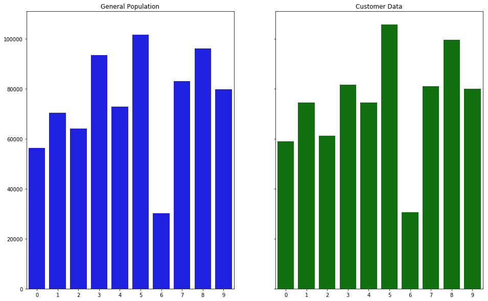

```python
fig, axes = plt.subplots(1,2, figsize=(16, 10), sharey=True)
sns.barplot(x=pop_unique[0], y=pop_unique[1], color='b', ax=axes[0]);
sns.barplot(x=cust_unique[0], y=cust_unique[1], color='g', ax=axes[1]);

axes[0].set_title('General Population')
axes[1].set_title('Customer Data');
```

The charts are different, but the differences are not well visualized. So now we will look at the differences:

```python
difference = np.subtract(cust_unique[1], pop_unique[1])
difference
```

```
array([  2655,   4179,  -2901, -11866,   1785,   4145,    488,  -2165,
         3335,    345])
```

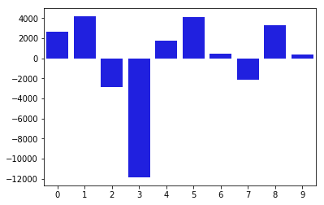

```python
sns.barplot(x=pop_unique[0], y=difference, color='b');
```

### Discussion

```python
# What kinds of people are part of a cluster that is overrepresented in the
# customer data compared to the general population?
df_cust_pca = pd.DataFrame(customers_pca, columns=np.arange(1, 14))
df_cust_pca['cluster'] = cust_labels
df_cust_pca.describe()
```

|  | 1 | 2 | 3 | 4 | 5 | 6 | 7 | 8 | 9 | 10 | 11 | 12 | 13 | cluster |
| --- | --- | --- | --- | --- | --- | --- | --- | --- | --- | --- | --- | --- | --- | --- |
| count | 7.471090e+05 | 7.471090e+05 | 7.471090e+05 | 7.471090e+05 | 7.471090e+05 | 7.471090e+05 | 7.471090e+05 | 7.471090e+05 | 7.471090e+05 | 7.471090e+05 | 7.471090e+05 | 7.471090e+05 | 7.471090e+05 | 747109.000000 |
| mean | 4.864463e-16 | -2.461619e-16 | -1.080533e-15 | -7.821297e-16 | 6.238264e-16 | 1.456828e-16 | 3.527753e-16 | -3.058787e-16 | 6.935103e-17 | 1.009261e-16 | -1.628208e-17 | 5.848711e-16 | -1.941391e-16 | 4.728566 |
| std | 3.420840e+00 | 3.117848e+00 | 2.580790e+00 | 2.061164e+00 | 1.904167e+00 | 1.673989e+00 | 1.587994e+00 | 1.403894e+00 | 1.439101e+00 | 1.536362e+00 | 1.449162e+00 | 1.157566e+00 | 1.101616e+00 | 2.854823 |
| min | -9.307187e+01 | -8.804873e+00 | -9.669468e+00 | -6.831736e+00 | -5.070503e+01 | -5.458039e+00 | -8.394290e+01 | -1.346261e+02 | -6.360304e+00 | -4.082542e+00 | -7.307687e+00 | -4.997784e+00 | -5.261259e+00 | 0.000000 |
| 25% | -2.984769e+00 | -2.503227e+00 | -2.305696e+00 | -1.488779e+00 | -1.452113e+00 | -1.224338e+00 | -1.079027e+00 | -8.997190e-01 | -9.282381e-01 | -1.028493e+00 | -8.912944e-01 | -7.361066e-01 | -7.219725e-01 | 2.000000 |
| 50% | -2.948234e-02 | 1.064898e-01 | -6.279557e-01 | 6.465369e-02 | -1.491271e-01 | -2.399354e-01 | -1.710858e-01 | 4.052583e-02 | 9.459942e-03 | -3.359478e-01 | 4.146842e-02 | -1.586859e-02 | -2.337505e-02 | 5.000000 |
| 75% | 2.832055e+00 | 2.397182e+00 | 2.404942e+00 | 1.457838e+00 | 1.447253e+00 | 1.096536e+00 | 8.744988e-01 | 9.430643e-01 | 9.504941e-01 | 5.555355e-01 | 9.308827e-01 | 7.158270e-01 | 7.126443e-01 | 7.000000 |
| max | 1.133323e+01 | 1.055407e+01 | 7.046478e+00 | 2.541472e+01 | 1.549565e+01 | 4.892667e+01 | 1.532221e+01 | 7.077974e+00 | 1.871732e+02 | 3.385123e+01 | 9.559793e+00 | 2.395272e+02 | 5.633249e+01 | 9.000000 |

```python
df_cust_pca.shape
```

```
(747109, 14)
```

```python
cluster_3 = df_cust_pca[df_cust_pca.cluster == 3]
cluster_3.shape
```

```
(81613, 14)
```

```python
cluster_3 = cluster_3.drop(columns='cluster')
cluster_3.head()
```

|  | 1 | 2 | 3 | 4 | 5 | 6 | 7 | 8 | 9 | 10 | 11 | 12 | 13 |
| --- | --- | --- | --- | --- | --- | --- | --- | --- | --- | --- | --- | --- | --- |
| 13 | -1.869597 | 0.364450 | 2.883141 | 3.714371 | -0.765420 | -0.933149 | -0.805632 | -0.727363 | -2.195075 | 2.850953 | 1.750960 | -1.404544 | -0.542349 |
| 19 | -4.654742 | 1.443856 | -0.742814 | 1.408042 | -2.597031 | -2.696695 | 0.028599 | -0.144443 | 1.366690 | -1.204623 | 0.000811 | -0.314799 | 0.566831 |
| 23 | -1.263302 | 0.938485 | -0.804098 | 2.896482 | -2.786117 | -3.548885 | -0.908595 | 0.595051 | 0.949497 | -0.432480 | 1.224614 | 0.001194 | -0.497436 |
| 27 | -4.175310 | -2.056171 | 3.836836 | 2.034792 | 2.498494 | -0.612930 | -0.785604 | 1.255952 | 0.027800 | -1.893309 | -1.061896 | -0.204491 | 0.413661 |
| 51 | -3.113091 | -2.512439 | 2.318547 | 3.039137 | 0.778727 | -1.641272 | -0.040456 | -2.259533 | -1.738625 | 0.518515 | -2.137736 | 2.396889 | 0.932152 |

```python
sums = cluster_3.sum(axis=0)
```

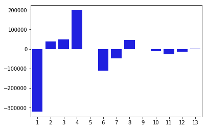

```python
sns.barplot(x=sums.keys(), y=sums, color='b');
```

### Component 1 Discussion

"We can summarize this component as low income people in high density housing"

### Component 2 Discussion

"Component two is characterized by a number of traits that seem to possibly be correlated with older age and conservativism:

-- lower financial preparation and financially inconspicuous, but higher rates of saving and investing

-- religious, traditional minded, low affinity for sensuality and events"

### Component 3 Discussion

"Component 3 centers around a cluster of personality traits:

-male

-down to earth, not particularly socially or family oriented, less interested in culture

-combative, dominant, critical, event oriented and rational"

### Component 4 Discussion

"Component 4 centers around these traits:

--higher income, from regions with higher purchasing power, greater representation of top earners

--more avantgarde and more likely to be involved with environmental sustainability

--less likely to be homeowners"